# Implementing the Brazilian National Health Survey Sampling Design in R: an Asthma Case Study

**Ingo Dube Souza**

MSc Program in Statistics and Data Science (PGECD/UFBA)

Department of Industrial Economics (SENAI/CIMATEC)

ingo.dube@ufba.br

**Maria Eduarda de Lima e Silva**

PhD in Applied Economics (UFRGS)

Department of Industrial Economics (SENAI/CIMATEC)

Methodological report

Technical report on estimators, confidence intervals, epidemiological indicators, and interpretation of PNS 2013–2019 asthma results.

19 October 2026

[Project repository](https://github.com/ingodube/PNS_2013_2019)

**Keywords:** National Health Survey; Sampling design; Asthma

**Contents**

# 1 Introduction

The PNS can estimate the frequency of asthma diagnosis and describe some experiences of care among adults. These estimates depend on both the sampling design and the questions participants received. This report documents the indicators, their denominators and the limits of comparisons between 2013 and 2019.

The survey measures self-reported diagnosis at any time in life. It can reflect disease occurrence and access to diagnosis, but does not by itself identify active asthma, current treatment needs or annual service use (Menezes et al., 2015).

## 1.1 Methodological revision note

This version replaces the previous results after reprocessing the microdata. Corrections cover the age domain, eligibility pathways, cause classification and income handling. Earlier PNS results in the Word document were not used. Validation includes recoding, weights, estimators and agreement of bilingual outputs. The change history and execution files are available in the repository.

# 2 Data source and analytical scope

Official PNS 2013 and 2019 microdata are used. These are repeated cross-sectional surveys, with no individual follow-up in this analysis. The selected resident was aged ≥18 years in 2013 and ≥15 years in 2019. All results in this report use the common domain aged ≥18 years. No age or sex standardisation was performed.

Import uses `labels = FALSE`, retaining official codes. Source data are cached outside Git. The manifest records files, hashes, versions and design checks. Rendering reads previously computed results.

# 3 Implementation of the complex sampling design

The design is constructed for all selected residents before defining analytical domains. It uses `UPA_PNS`, `V0024` and initial weight `V0029`, followed by post-stratification on `V00293` using totals `V00292`. Each domain is explicitly paired with its total. Resulting weights are checked against `V00291`, with relative tolerance 10⁻⁶ for file precision; totals must be recovered with relative error below 10⁻¹⁰.

The object represents strata and clusters available for variance estimation; it does not explicitly reconstruct every selection stage or sampling fraction. Age, diagnosis and geographical restrictions are domain operations (Souza-Júnior et al., 2015; Lumley, 2010).

`survey.lonely.psu = "adjust"` handles strata with a single PSU. The additional option for lonely domains does not guarantee adjustment in post-stratified designs. Outputs include PSU and stratum counts, degrees of freedom, strata with only one PSU in the domain (`lonely_strata_n`) and estimability status. This count flags a precision limitation; a calculable CI does not remove that limitation.

Design checks

| Year | Selected | Adults | Under 18 | Invalid age |
| --- | --- | --- | --- | --- |
| 2013 | 60202 | 60202 | 0 | 0 |
| 2019 | 90846 | 88531 | 2315 | 0 |

Source: authors’ calculations using official PNS microdata.

# 4 Estimators and confidence intervals

Proportions and means are ratios of weighted sums among eligible respondents with valid information. Ignored responses, unknown eligibility and inapplicable questions are distinguished during recoding. The missing column in the tables is the weighted percentage of invalid information within the eligible domain. Missing answers to preceding questions can prevent eligibility from being determined.

Proportions use `svymean()` for the estimate and standard error and `svyciprop(method = "beta")` for the 95% CI (Korn and Graubard, 1998). Means use a t approximation with domain degrees of freedom. Observed proportions of zero or one are reported with a non-estimable CI; empty domains and unavailable variances have explicit statuses.

Differences in diagnosis, attacks and smoking are expressed in percentage points. The standard error combines edition-specific variances under an independence approximation; the CI uses Welch–Satterthwaite degrees of freedom. Covariance between editions is not estimated. National contrasts are prioritised; state contrasts are exploratory, without confirmatory interpretation. Overlap of individual CIs does not test difference or equivalence.

$$\widehat{\theta}_D = \frac{\sum_{i \in D} w_i y_i}{\sum_{i \in D} w_i}, \qquad SE(\widehat{\Delta}) = \sqrt{\widehat{V}_{2019}+\widehat{V}_{2013}}.$$

# 5 Asthma indicators and context

## 5.1 Self-reported medical diagnosis

Numerator: a positive answer to `Q074`. Denominator: adults with a valid answer. Lifetime diagnosis can be affected by population composition and access to diagnosis.

2013: 4.41% [4.13%; 4.71%]; n = 60202. 2019: 5.27% [5.00%; 5.55%]; n = 88531.

Self-reported medical diagnosis

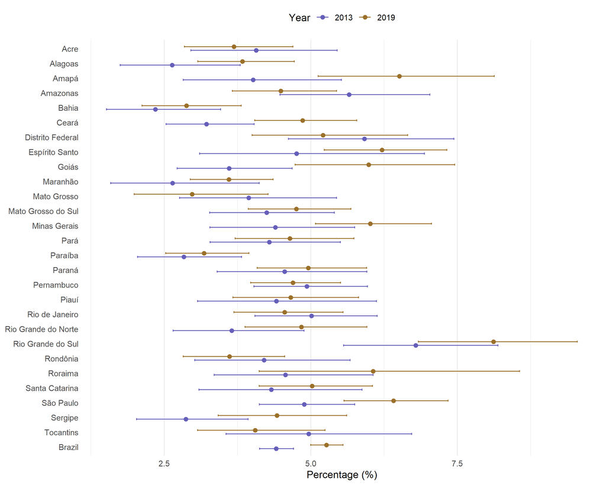

Self-reported medical diagnosis

| UF | Year | Estimate [95% CI] | Valid n | Missing (%) |
| --- | --- | --- | --- | --- |
| Acre | 2013 | 4.07% [2.95%; 5.45%] | 1814 | 0.00 |
| Acre | 2019 | 3.69% [2.84%; 4.69%] | 2283 | 0.00 |
| Alagoas | 2013 | 2.63% [1.75%; 3.79%] | 1748 | 0.00 |
| Alagoas | 2019 | 3.83% [3.07%; 4.72%] | 2898 | 0.00 |
| Amapá | 2013 | 4.02% [2.82%; 5.52%] | 1332 | 0.00 |
| Amapá | 2019 | 6.51% [5.13%; 8.13%] | 1473 | 0.00 |
| Amazonas | 2013 | 5.65% [4.47%; 7.03%] | 2586 | 0.00 |
| Amazonas | 2019 | 4.49% [3.66%; 5.44%] | 3370 | 0.00 |
| Bahia | 2013 | 2.35% [1.51%; 3.46%] | 2641 | 0.00 |
| Bahia | 2019 | 2.88% [2.12%; 3.81%] | 3600 | 0.00 |
| Ceará | 2013 | 3.22% [2.53%; 4.03%] | 2560 | 0.00 |
| Ceará | 2019 | 4.86% [4.04%; 5.78%] | 4141 | 0.00 |
| Distrito Federal | 2013 | 5.91% [4.62%; 7.44%] | 1811 | 0.00 |
| Distrito Federal | 2019 | 5.21% [4.00%; 6.65%] | 2305 | 0.00 |
| Espírito Santo | 2013 | 4.76% [3.10%; 6.94%] | 1724 | 0.00 |
| Espírito Santo | 2019 | 6.21% [5.23%; 7.32%] | 3463 | 0.00 |
| Goiás | 2013 | 3.61% [2.72%; 4.68%] | 2423 | 0.00 |
| Goiás | 2019 | 5.99% [4.73%; 7.45%] | 2648 | 0.00 |
| Maranhão | 2013 | 2.64% [1.59%; 4.12%] | 1774 | 0.00 |
| Maranhão | 2019 | 3.60% [2.94%; 4.36%] | 4889 | 0.00 |
| Mato Grosso | 2013 | 3.94% [2.76%; 5.44%] | 1476 | 0.00 |
| Mato Grosso | 2019 | 2.97% [1.98%; 4.27%] | 2423 | 0.00 |
| Mato Grosso do Sul | 2013 | 4.24% [3.28%; 5.40%] | 1809 | 0.00 |
| Mato Grosso do Sul | 2019 | 4.75% [3.93%; 5.68%] | 2805 | 0.00 |
| Minas Gerais | 2013 | 4.39% [3.28%; 5.75%] | 3779 | 0.00 |
| Minas Gerais | 2019 | 6.01% [5.08%; 7.06%] | 5128 | 0.00 |
| Pará | 2013 | 4.29% [3.28%; 5.50%] | 2004 | 0.00 |
| Pará | 2019 | 4.64% [3.71%; 5.74%] | 3696 | 0.00 |
| Paraíba | 2013 | 2.83% [2.05%; 3.82%] | 1943 | 0.00 |
| Paraíba | 2019 | 3.18% [2.52%; 3.94%] | 3068 | 0.00 |
| Paraná | 2013 | 4.55% [3.40%; 5.96%] | 3012 | 0.00 |
| Paraná | 2019 | 4.96% [4.09%; 5.95%] | 3893 | 0.00 |
| Pernambuco | 2013 | 4.93% [4.03%; 5.97%] | 2591 | 0.00 |
| Pernambuco | 2019 | 4.70% [3.97%; 5.51%] | 3992 | 0.00 |
| Piauí | 2013 | 4.41% [3.07%; 6.12%] | 1804 | 0.00 |
| Piauí | 2019 | 4.66% [3.67%; 5.82%] | 2674 | 0.00 |
| Rio de Janeiro | 2013 | 5.01% [4.04%; 6.13%] | 3486 | 0.00 |
| Rio de Janeiro | 2019 | 4.55% [3.69%; 5.55%] | 4849 | 0.00 |
| Rio Grande do Norte | 2013 | 3.65% [2.65%; 4.88%] | 1691 | 0.00 |
| Rio Grande do Norte | 2019 | 4.84% [3.88%; 5.95%] | 2877 | 0.00 |
| Rio Grande do Sul | 2013 | 6.79% [5.56%; 8.19%] | 2913 | 0.00 |
| Rio Grande do Sul | 2019 | 8.11% [6.84%; 9.55%] | 3707 | 0.00 |
| Rondônia | 2013 | 4.20% [3.02%; 5.67%] | 1694 | 0.00 |
| Rondônia | 2019 | 3.61% [2.82%; 4.55%] | 2108 | 0.00 |
| Roraima | 2013 | 4.57% [3.35%; 6.06%] | 1591 | 0.00 |
| Roraima | 2019 | 6.06% [4.12%; 8.56%] | 2135 | 0.00 |
| Santa Catarina | 2013 | 4.33% [3.09%; 5.87%] | 1623 | 0.00 |
| Santa Catarina | 2019 | 5.02% [4.12%; 6.05%] | 3676 | 0.00 |
| São Paulo | 2013 | 4.89% [4.12%; 5.75%] | 5305 | 0.00 |
| São Paulo | 2019 | 6.41% [5.57%; 7.34%] | 5995 | 0.00 |
| Sergipe | 2013 | 2.87% [2.03%; 3.93%] | 1553 | 0.00 |
| Sergipe | 2019 | 4.42% [3.42%; 5.61%] | 2563 | 0.00 |
| Tocantins | 2013 | 4.96% [3.55%; 6.72%] | 1515 | 0.00 |
| Tocantins | 2019 | 4.05% [3.07%; 5.24%] | 1872 | 0.00 |
| Brazil | 2013 | 4.41% [4.13%; 4.71%] | 60202 | 0.00 |
| Brazil | 2019 | 5.27% [5.00%; 5.55%] | 88531 | 0.00 |

Source: authors’ calculations using official PNS microdata.

## 5.2 Attacks in the previous 12 months

Numerator: a positive answer to `Q076`. Denominator: adults with a diagnosis and a valid answer about attacks.

2013: 38.29% [34.93%; 41.73%]; n = 2620. 2019: 37.64% [35.04%; 40.29%]; n = 4294.

Attacks in the previous 12 months

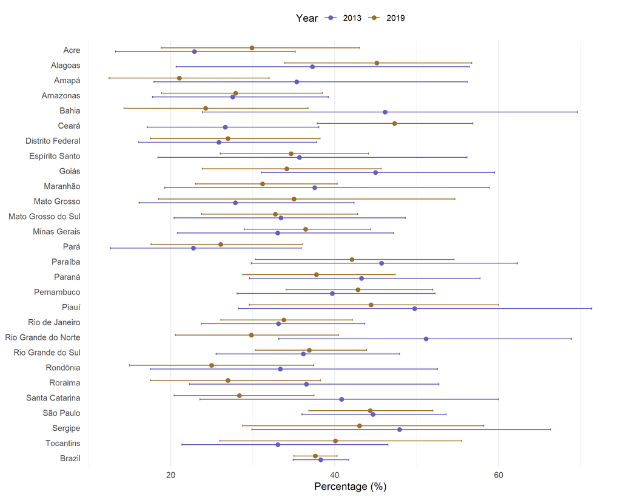

Attacks in the previous 12 months

| UF | Year | Estimate [95% CI] | Valid n | Missing (%) |
| --- | --- | --- | --- | --- |
| Acre | 2013 | 22.88% [13.24%; 35.19%] | 66 | 0.00 |
| Acre | 2019 | 29.90% [18.82%; 43.03%] | 87 | 0.00 |
| Alagoas | 2013 | 37.28% [20.66%; 56.43%] | 43 | 0.00 |
| Alagoas | 2019 | 45.14% [33.92%; 56.73%] | 111 | 0.00 |
| Amapá | 2013 | 35.37% [17.94%; 56.20%] | 53 | 0.00 |
| Amapá | 2019 | 21.03% [12.47%; 31.99%] | 87 | 0.00 |
| Amazonas | 2013 | 27.56% [17.78%; 39.21%] | 129 | 0.00 |
| Amazonas | 2019 | 27.89% [18.85%; 38.48%] | 144 | 0.00 |
| Bahia | 2013 | 46.15% [23.88%; 69.61%] | 65 | 0.00 |
| Bahia | 2019 | 24.24% [14.29%; 36.74%] | 110 | 0.00 |
| Ceará | 2013 | 26.63% [17.10%; 38.06%] | 103 | 0.00 |
| Ceará | 2019 | 47.30% [37.89%; 56.85%] | 191 | 0.00 |
| Distrito Federal | 2013 | 25.86% [16.09%; 37.78%] | 98 | 0.00 |
| Distrito Federal | 2019 | 26.97% [17.55%; 38.21%] | 120 | 0.00 |
| Espírito Santo | 2013 | 35.67% [18.44%; 56.14%] | 92 | 0.00 |
| Espírito Santo | 2019 | 34.67% [26.03%; 44.11%] | 217 | 0.00 |
| Goiás | 2013 | 44.98% [31.05%; 59.52%] | 92 | 0.00 |
| Goiás | 2019 | 34.13% [23.84%; 45.66%] | 143 | 0.00 |
| Maranhão | 2013 | 37.54% [19.27%; 58.85%] | 46 | 0.00 |
| Maranhão | 2019 | 31.19% [23.02%; 40.31%] | 163 | 0.00 |
| Mato Grosso | 2013 | 27.86% [16.12%; 42.34%] | 53 | 0.00 |
| Mato Grosso | 2019 | 35.03% [18.51%; 54.67%] | 66 | 0.00 |
| Mato Grosso do Sul | 2013 | 33.43% [20.40%; 48.61%] | 77 | 0.00 |
| Mato Grosso do Sul | 2019 | 32.76% [23.75%; 42.80%] | 140 | 0.00 |
| Minas Gerais | 2013 | 33.04% [20.84%; 47.17%] | 191 | 0.00 |
| Minas Gerais | 2019 | 36.43% [28.97%; 44.41%] | 308 | 0.00 |
| Pará | 2013 | 22.75% [12.62%; 35.91%] | 112 | 0.00 |
| Pará | 2019 | 26.08% [17.60%; 36.10%] | 166 | 0.00 |
| Paraíba | 2013 | 45.72% [29.81%; 62.29%] | 65 | 0.00 |
| Paraíba | 2019 | 42.09% [30.33%; 54.55%] | 118 | 0.00 |
| Paraná | 2013 | 43.26% [29.59%; 57.74%] | 153 | 0.00 |
| Paraná | 2019 | 37.75% [28.78%; 47.39%] | 192 | 0.00 |
| Pernambuco | 2013 | 39.71% [28.08%; 52.25%] | 129 | 0.00 |
| Pernambuco | 2019 | 42.83% [34.05%; 51.94%] | 191 | 0.00 |
| Piauí | 2013 | 49.75% [28.22%; 71.36%] | 60 | 0.00 |
| Piauí | 2019 | 44.42% [29.60%; 60.00%] | 115 | 0.00 |
| Rio de Janeiro | 2013 | 33.14% [23.71%; 43.68%] | 153 | 0.00 |
| Rio de Janeiro | 2019 | 33.79% [26.11%; 42.15%] | 207 | 0.00 |
| Rio Grande do Norte | 2013 | 51.13% [33.18%; 68.87%] | 63 | 0.00 |
| Rio Grande do Norte | 2019 | 29.81% [20.56%; 40.46%] | 148 | 0.00 |
| Rio Grande do Sul | 2013 | 36.17% [25.52%; 47.93%] | 198 | 0.00 |
| Rio Grande do Sul | 2019 | 36.90% [30.30%; 43.89%] | 309 | 0.00 |
| Rondônia | 2013 | 33.37% [17.53%; 52.52%] | 58 | 0.00 |
| Rondônia | 2019 | 24.98% [14.97%; 37.42%] | 81 | 0.00 |
| Roraima | 2013 | 36.53% [22.30%; 52.72%] | 68 | 0.00 |
| Roraima | 2019 | 26.97% [17.52%; 38.25%] | 100 | 0.00 |
| Santa Catarina | 2013 | 40.83% [23.55%; 59.96%] | 88 | 0.00 |
| Santa Catarina | 2019 | 28.37% [20.40%; 37.47%] | 208 | 0.00 |
| São Paulo | 2013 | 44.68% [36.01%; 53.60%] | 244 | 0.00 |
| São Paulo | 2019 | 44.31% [36.85%; 51.97%] | 386 | 0.00 |
| Sergipe | 2013 | 47.92% [29.90%; 66.34%] | 46 | 0.00 |
| Sergipe | 2019 | 43.02% [28.76%; 58.18%] | 108 | 0.00 |
| Tocantins | 2013 | 33.05% [21.36%; 46.50%] | 75 | 0.00 |
| Tocantins | 2019 | 40.08% [25.97%; 55.50%] | 78 | 0.00 |
| Brazil | 2013 | 38.29% [34.93%; 41.73%] | 2620 | 0.00 |
| Brazil | 2019 | 37.64% [35.04%; 40.29%] | 4294 | 0.00 |

Source: authors’ calculations using official PNS microdata.

## 5.3 Medication: edition-specific populations

In 2013, `Q07701` measures current use among adults with a diagnosis and an attack in the previous 12 months. In 2019, `Q07704` and `Q07708` measure oral medication and inhaler use in the previous two weeks, following diagnosis, an attack and prescription. Combined use is positive when either modality has a valid positive answer; non-use requires valid negative answers to both. Estimates are edition-specific and do not support a temporal contrast of access.

2013: 81.50% [77.08%; 85.39%]; n = 961. 2019: 65.65% [60.63%; 70.43%]; n = 1368.

Medication: edition-specific populations

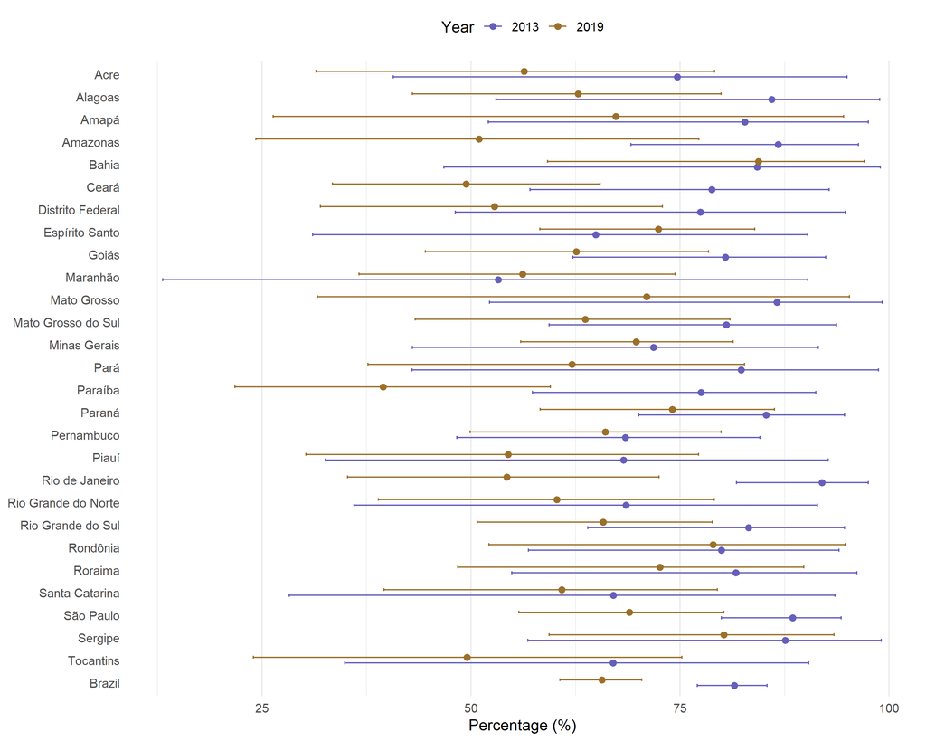

Medication: edition-specific populations

| UF | Year | Estimate [95% CI] | Valid n | Missing (%) |
| --- | --- | --- | --- | --- |
| Acre | 2013 | 74.66% [40.69%; 94.95%] | 19 | 0.00 |
| Acre | 2019 | 56.37% [31.46%; 79.11%] | 23 | 0.00 |
| Alagoas | 2013 | 85.95% [53.01%; 98.88%] | 16 | 0.00 |
| Alagoas | 2019 | 62.81% [42.98%; 79.92%] | 46 | 0.00 |
| Amapá | 2013 | 82.76% [52.06%; 97.51%] | 18 | 0.00 |
| Amapá | 2019 | 67.30% [26.36%; 94.55%] | 14 | 0.00 |
| Amazonas | 2013 | 86.72% [69.11%; 96.34%] | 37 | 0.00 |
| Amazonas | 2019 | 50.95% [24.27%; 77.24%] | 26 | 0.00 |
| Bahia | 2013 | 84.22% [46.76%; 98.95%] | 25 | 0.00 |
| Bahia | 2019 | 84.35% [59.16%; 97.02%] | 27 | 0.00 |
| Ceará | 2013 | 78.81% [57.04%; 92.82%] | 34 | 0.00 |
| Ceará | 2019 | 49.40% [33.45%; 65.44%] | 78 | 0.00 |
| Distrito Federal | 2013 | 77.45% [48.12%; 94.77%] | 29 | 0.00 |
| Distrito Federal | 2019 | 52.79% [32.00%; 72.90%] | 34 | 0.00 |
| Espírito Santo | 2013 | 64.90% [31.06%; 90.27%] | 35 | 0.00 |
| Espírito Santo | 2019 | 72.41% [58.25%; 83.91%] | 76 | 0.00 |
| Goiás | 2013 | 80.41% [62.18%; 92.43%] | 43 | 0.00 |
| Goiás | 2019 | 62.59% [44.55%; 78.39%] | 55 | 0.00 |
| Maranhão | 2013 | 53.24% [13.14%; 90.29%] | 15 | 0.00 |
| Maranhão | 2019 | 56.17% [36.62%; 74.41%] | 38 | 0.00 |
| Mato Grosso | 2013 | 86.59% [52.22%; 99.17%] | 16 | 0.00 |
| Mato Grosso | 2019 | 71.01% [31.62%; 95.26%] | 21 | 0.00 |
| Mato Grosso do Sul | 2013 | 80.53% [59.33%; 93.70%] | 30 | 0.00 |
| Mato Grosso do Sul | 2019 | 63.67% [43.33%; 80.97%] | 40 | 0.00 |
| Minas Gerais | 2013 | 71.82% [42.98%; 91.53%] | 68 | 0.00 |
| Minas Gerais | 2019 | 69.75% [55.94%; 81.36%] | 113 | 0.00 |
| Pará | 2013 | 82.30% [42.94%; 98.73%] | 25 | 0.00 |
| Pará | 2019 | 62.09% [37.68%; 82.70%] | 41 | 0.00 |
| Paraíba | 2013 | 77.50% [57.34%; 91.24%] | 27 | 0.00 |
| Paraíba | 2019 | 39.49% [21.76%; 59.50%] | 41 | 0.00 |
| Paraná | 2013 | 85.31% [70.04%; 94.67%] | 61 | 0.00 |
| Paraná | 2019 | 74.05% [58.28%; 86.29%] | 66 | 0.00 |
| Pernambuco | 2013 | 68.46% [48.32%; 84.54%] | 53 | 0.00 |
| Pernambuco | 2019 | 66.07% [49.90%; 79.90%] | 68 | 0.00 |
| Piauí | 2013 | 68.25% [32.59%; 92.72%] | 22 | 0.00 |
| Piauí | 2019 | 54.45% [30.24%; 77.20%] | 39 | 0.00 |
| Rio de Janeiro | 2013 | 91.98% [81.73%; 97.50%] | 51 | 0.00 |
| Rio de Janeiro | 2019 | 54.29% [35.22%; 72.47%] | 61 | 0.00 |
| Rio Grande do Norte | 2013 | 68.53% [36.02%; 91.41%] | 28 | 0.00 |
| Rio Grande do Norte | 2019 | 60.28% [38.93%; 79.11%] | 41 | 0.00 |
| Rio Grande do Sul | 2013 | 83.19% [63.97%; 94.68%] | 68 | 0.00 |
| Rio Grande do Sul | 2019 | 65.81% [50.75%; 78.86%] | 102 | 0.00 |
| Rondônia | 2013 | 79.94% [56.88%; 94.02%] | 25 | 0.00 |
| Rondônia | 2019 | 78.95% [52.16%; 94.73%] | 22 | 0.00 |
| Roraima | 2013 | 81.69% [54.87%; 96.15%] | 24 | 0.00 |
| Roraima | 2019 | 72.60% [48.43%; 89.80%] | 26 | 0.00 |
| Santa Catarina | 2013 | 67.01% [28.27%; 93.54%] | 36 | 0.00 |
| Santa Catarina | 2019 | 60.85% [39.61%; 79.45%] | 53 | 0.00 |
| São Paulo | 2013 | 88.46% [79.92%; 94.26%] | 106 | 0.00 |
| São Paulo | 2019 | 68.96% [55.73%; 80.24%] | 158 | 0.00 |
| Sergipe | 2013 | 87.58% [56.79%; 99.07%] | 22 | 0.00 |
| Sergipe | 2019 | 80.23% [59.33%; 93.40%] | 32 | 0.00 |
| Tocantins | 2013 | 66.97% [34.92%; 90.38%] | 28 | 0.00 |
| Tocantins | 2019 | 49.52% [23.99%; 75.23%] | 27 | 0.00 |
| Brazil | 2013 | 81.50% [77.08%; 85.39%] | 961 | 0.00 |
| Brazil | 2019 | 65.65% [60.63%; 70.43%] | 1368 | 0.00 |

Source: authors’ calculations using official PNS microdata.

### 5.3.1 Discontinued indicators

Duplicated presentations of general use and use following an attack have been replaced by the conditional indicator above. The population rate was withdrawn: routing does not observe use among all adults with a diagnosis. Questionnaire-generated missingness does not demonstrate absence of treatment.

# 6 Current smoking

`P050` identifies daily or less-than-daily tobacco use. The denominator contains adults with valid responses. Results are percentages of adults.

2013: 14.65% [14.17%; 15.14%]; n = 60202. 2019: 12.59% [12.19%; 12.99%]; n = 88531.

Current smoking

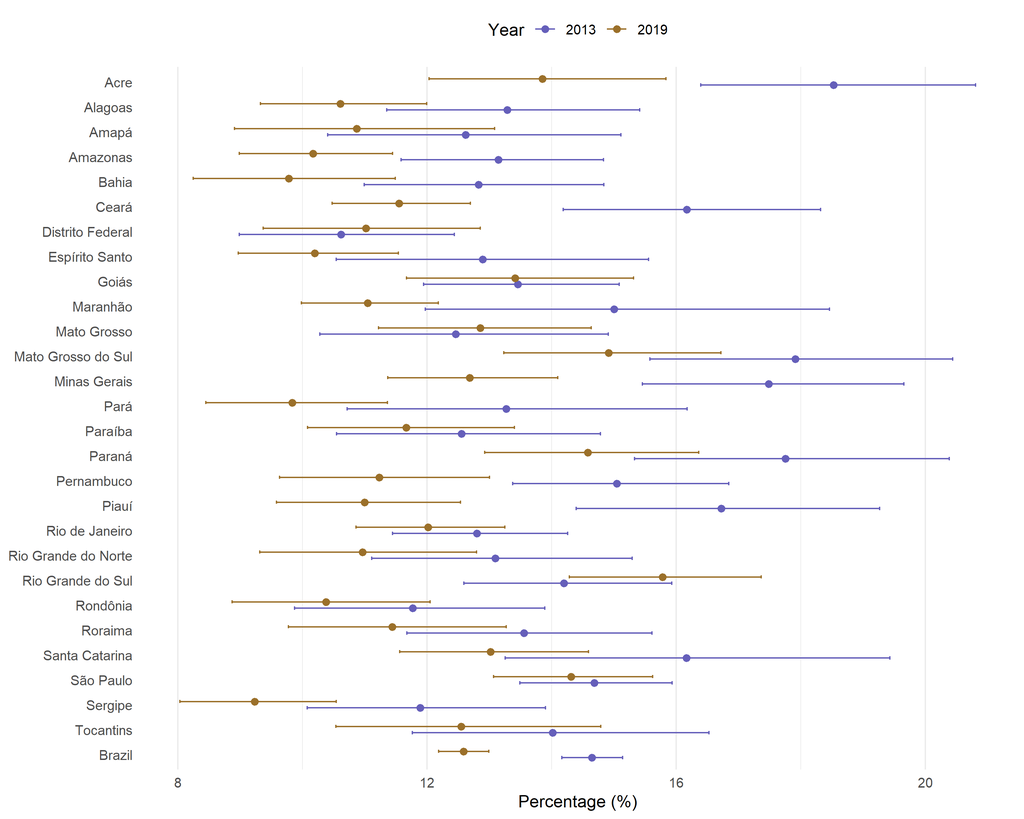

Current smoking

| UF | Year | Estimate [95% CI] | Valid n | Missing (%) |
| --- | --- | --- | --- | --- |
| Acre | 2013 | 18.53% [16.40%; 20.81%] | 1814 | 0.00 |
| Acre | 2019 | 13.86% [12.04%; 15.84%] | 2283 | 0.00 |
| Alagoas | 2013 | 13.29% [11.35%; 15.42%] | 1748 | 0.00 |
| Alagoas | 2019 | 10.61% [9.33%; 11.99%] | 2898 | 0.00 |
| Amapá | 2013 | 12.62% [10.41%; 15.11%] | 1332 | 0.00 |
| Amapá | 2019 | 10.87% [8.91%; 13.09%] | 1473 | 0.00 |
| Amazonas | 2013 | 13.15% [11.58%; 14.84%] | 2586 | 0.00 |
| Amazonas | 2019 | 10.17% [8.99%; 11.45%] | 3370 | 0.00 |
| Bahia | 2013 | 12.83% [11.00%; 14.84%] | 2641 | 0.00 |
| Bahia | 2019 | 9.78% [8.25%; 11.49%] | 3600 | 0.00 |
| Ceará | 2013 | 16.17% [14.19%; 18.32%] | 2560 | 0.00 |
| Ceará | 2019 | 11.55% [10.48%; 12.70%] | 4141 | 0.00 |
| Distrito Federal | 2013 | 10.62% [8.98%; 12.44%] | 1811 | 0.00 |
| Distrito Federal | 2019 | 11.02% [9.37%; 12.86%] | 2305 | 0.00 |
| Espírito Santo | 2013 | 12.90% [10.54%; 15.56%] | 1724 | 0.00 |
| Espírito Santo | 2019 | 10.20% [8.97%; 11.54%] | 3463 | 0.00 |
| Goiás | 2013 | 13.46% [11.95%; 15.09%] | 2423 | 0.00 |
| Goiás | 2019 | 13.42% [11.67%; 15.32%] | 2648 | 0.00 |
| Maranhão | 2013 | 15.00% [11.97%; 18.46%] | 1774 | 0.00 |
| Maranhão | 2019 | 11.05% [9.98%; 12.18%] | 4889 | 0.00 |
| Mato Grosso | 2013 | 12.46% [10.28%; 14.91%] | 1476 | 0.00 |
| Mato Grosso | 2019 | 12.86% [11.23%; 14.64%] | 2423 | 0.00 |
| Mato Grosso do Sul | 2013 | 17.91% [15.58%; 20.44%] | 1809 | 0.00 |
| Mato Grosso do Sul | 2019 | 14.91% [13.23%; 16.72%] | 2805 | 0.00 |
| Minas Gerais | 2013 | 17.48% [15.46%; 19.66%] | 3779 | 0.00 |
| Minas Gerais | 2019 | 12.69% [11.37%; 14.10%] | 5128 | 0.00 |
| Pará | 2013 | 13.27% [10.72%; 16.18%] | 2004 | 0.00 |
| Pará | 2019 | 9.84% [8.45%; 11.37%] | 3696 | 0.00 |
| Paraíba | 2013 | 12.55% [10.55%; 14.79%] | 1943 | 0.00 |
| Paraíba | 2019 | 11.67% [10.08%; 13.40%] | 3068 | 0.00 |
| Paraná | 2013 | 17.76% [15.33%; 20.39%] | 3012 | 0.00 |
| Paraná | 2019 | 14.58% [12.93%; 16.37%] | 3893 | 0.00 |
| Pernambuco | 2013 | 15.05% [13.38%; 16.85%] | 2591 | 0.00 |
| Pernambuco | 2019 | 11.24% [9.63%; 13.00%] | 3992 | 0.00 |
| Piauí | 2013 | 16.73% [14.40%; 19.27%] | 1804 | 0.00 |
| Piauí | 2019 | 11.00% [9.59%; 12.54%] | 2674 | 0.00 |
| Rio de Janeiro | 2013 | 12.80% [11.45%; 14.26%] | 3486 | 0.00 |
| Rio de Janeiro | 2019 | 12.02% [10.86%; 13.25%] | 4849 | 0.00 |
| Rio Grande do Norte | 2013 | 13.10% [11.11%; 15.29%] | 1691 | 0.00 |
| Rio Grande do Norte | 2019 | 10.97% [9.31%; 12.80%] | 2877 | 0.00 |
| Rio Grande do Sul | 2013 | 14.20% [12.59%; 15.93%] | 2913 | 0.00 |
| Rio Grande do Sul | 2019 | 15.78% [14.29%; 17.37%] | 3707 | 0.00 |
| Rondônia | 2013 | 11.77% [9.87%; 13.89%] | 1694 | 0.00 |
| Rondônia | 2019 | 10.38% [8.87%; 12.05%] | 2108 | 0.00 |
| Roraima | 2013 | 13.56% [11.68%; 15.61%] | 1591 | 0.00 |
| Roraima | 2019 | 11.44% [9.78%; 13.27%] | 2135 | 0.00 |
| Santa Catarina | 2013 | 16.17% [13.26%; 19.43%] | 1623 | 0.00 |
| Santa Catarina | 2019 | 13.02% [11.56%; 14.59%] | 3676 | 0.00 |
| São Paulo | 2013 | 14.68% [13.49%; 15.94%] | 5305 | 0.00 |
| São Paulo | 2019 | 14.31% [13.07%; 15.63%] | 5995 | 0.00 |
| Sergipe | 2013 | 11.89% [10.08%; 13.90%] | 1553 | 0.00 |
| Sergipe | 2019 | 9.23% [8.04%; 10.54%] | 2563 | 0.00 |
| Tocantins | 2013 | 14.02% [11.76%; 16.53%] | 1515 | 0.00 |
| Tocantins | 2019 | 12.55% [10.54%; 14.79%] | 1872 | 0.00 |
| Brazil | 2013 | 14.65% [14.17%; 15.14%] | 60202 | 0.00 |
| Brazil | 2019 | 12.59% [12.19%; 12.99%] | 88531 | 0.00 |

Source: authors’ calculations using official PNS microdata.

# 7 National contrasts

The intervals below directly describe the difference between editions. A difference compatible with zero does not demonstrate equivalence. Without standardisation, changes in age or sex composition can contribute to the contrast.

National differences: 2019 minus 2013

| Indicator | Difference (p.p.) | 95% CI |
| --- | --- | --- |
| Asthma attacks | -0.65 | [-4.88; 3.58] |
| Asthma diagnosis | 0.86 | [0.46; 1.26] |
| Current smoking | -2.06 | [-2.69; -1.43] |

Source: authors’ calculations using official PNS microdata.

# 8 Payment for medication

In 2019, payment is described among eligible oral medication users (`Q07707`) and inhaler users (`Q07711`). Denominators require diagnosis, an attack, prescription and modality use. Answers do not measure the amount paid, total household costs or catastrophic expenditure. This section does not estimate Farmácia Popular coverage.

Payment for medication

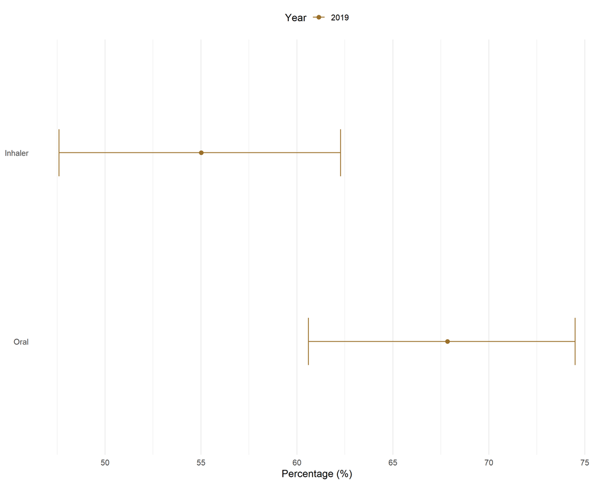

Payment for medication

| Indicator | UF | Year | Estimate [95% CI] | Valid n | Missing (%) |
| --- | --- | --- | --- | --- | --- |
| Inhaler | Brazil | 2019 | 55.02% [47.60%; 62.28%] | 681 | 0.00 |
| Oral | Brazil | 2019 | 67.84% [60.60%; 74.50%] | 796 | 0.00 |

Source: authors’ calculations using official PNS microdata.

# 9 Usual activities and income

This section describes adults without restriction to people with asthma. Usual activities include household, school, leisure and work activities; their restriction does not measure work absence exclusively.

## 9.1 Health-related activity restriction

`J002` identifies interruption of activities in the previous two weeks. The denominator contains adults with a valid answer.

2013: 8.00% [7.63%; 8.40%]; n = 60202. 2019: 8.88% [8.57%; 9.20%]; n = 88531.

Health-related activity restriction

| UF | Year | Estimate [95% CI] | Valid n | Missing (%) |
| --- | --- | --- | --- | --- |
| Brazil | 2013 | 8.00% [7.63%; 8.40%] | 60202 | 0.00 |
| Brazil | 2019 | 8.88% [8.57%; 9.20%] | 88531 | 0.00 |

Source: authors’ calculations using official PNS microdata.

## 9.2 Distribution of causes among adults with restriction

In 2019, each cause is estimated among adults with restriction and a valid answer to `J00402`. Ignored responses are excluded from the denominator and recorded as missing. Classification uses official codes.

Distribution of causes among adults with restriction

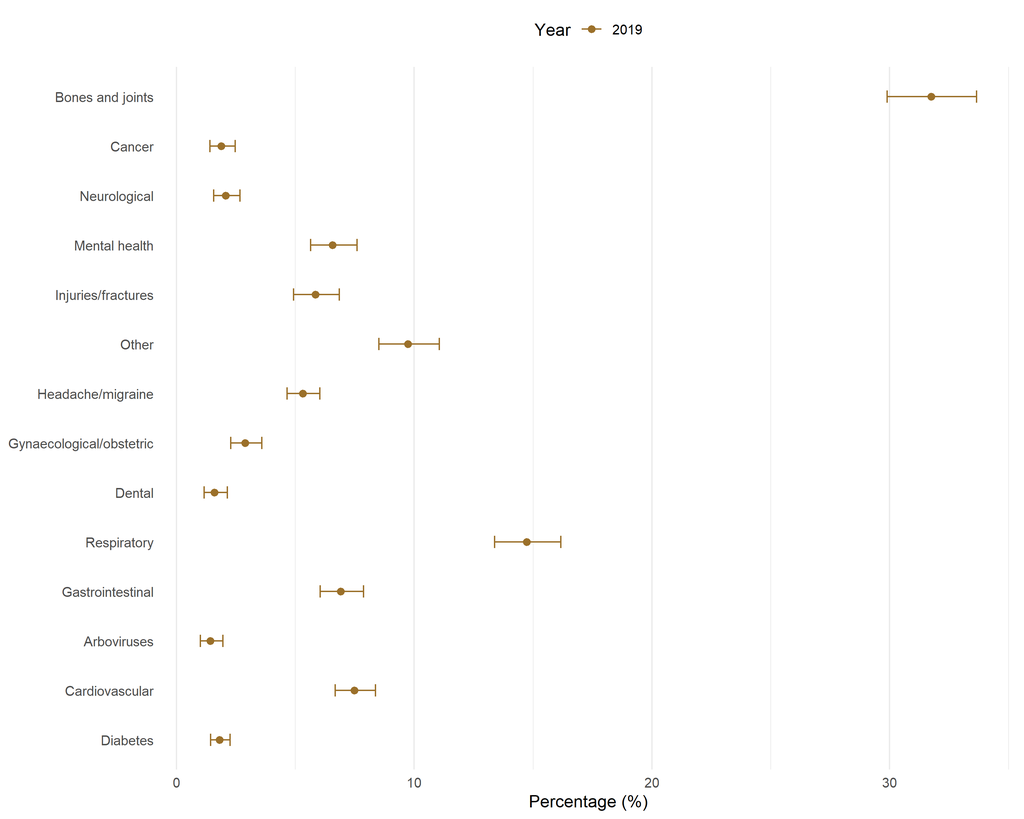

Distribution of causes among adults with restriction

| Indicator | UF | Year | Estimate [95% CI] | Valid n | Missing (%) |
| --- | --- | --- | --- | --- | --- |
| Bones and joints | Brazil | 2019 | 31.75% [29.89%; 33.65%] | 8693 | 0.00 |
| Cancer | Brazil | 2019 | 1.88% [1.41%; 2.47%] | 8693 | 0.00 |
| Neurological | Brazil | 2019 | 2.07% [1.57%; 2.67%] | 8693 | 0.00 |
| Mental health | Brazil | 2019 | 6.56% [5.64%; 7.59%] | 8693 | 0.00 |
| Injuries/fractures | Brazil | 2019 | 5.84% [4.93%; 6.85%] | 8693 | 0.00 |
| Other | Brazil | 2019 | 9.73% [8.52%; 11.06%] | 8693 | 0.00 |
| Headache/migraine | Brazil | 2019 | 5.31% [4.66%; 6.03%] | 8693 | 0.00 |
| Gynaecological/obstetric | Brazil | 2019 | 2.88% [2.28%; 3.60%] | 8693 | 0.00 |
| Dental | Brazil | 2019 | 1.60% [1.17%; 2.14%] | 8693 | 0.00 |
| Respiratory | Brazil | 2019 | 14.73% [13.38%; 16.16%] | 8693 | 0.00 |
| Gastrointestinal | Brazil | 2019 | 6.91% [6.04%; 7.87%] | 8693 | 0.00 |
| Arboviruses | Brazil | 2019 | 1.42% [1.00%; 1.95%] | 8693 | 0.00 |
| Cardiovascular | Brazil | 2019 | 7.49% [6.67%; 8.37%] | 8693 | 0.00 |
| Diabetes | Brazil | 2019 | 1.81% [1.43%; 2.26%] | 8693 | 0.00 |

Source: authors’ calculations using official PNS microdata.

## 9.3 Days of restriction by cause

Means of `J003` are conditional on the corresponding cause being present. Values from 1 to 14 days are valid; ignored codes remain missing. Means describe intensity among affected people, without an interpretation as annual productivity loss.

Days of restriction by cause

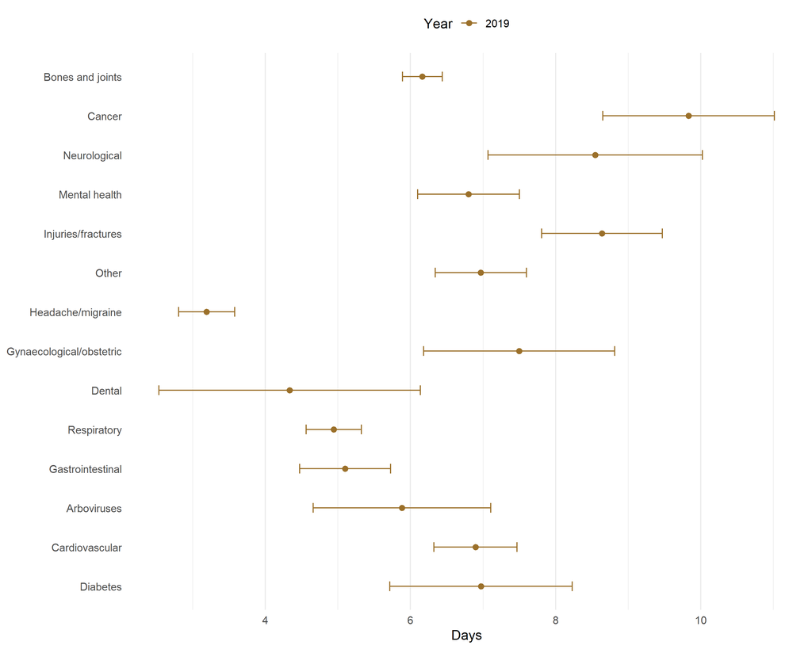

Days of restriction by cause

| Indicator | UF | Year | Estimate [95% CI] | Valid n | Missing (%) |
| --- | --- | --- | --- | --- | --- |
| Bones and joints | Brazil | 2019 | 6.16 [5.89; 6.44] | 2887 | 0.00 |
| Cancer | Brazil | 2019 | 9.83 [8.65; 11.01] | 139 | 0.00 |
| Neurological | Brazil | 2019 | 8.54 [7.07; 10.02] | 160 | 0.00 |
| Mental health | Brazil | 2019 | 6.80 [6.10; 7.50] | 524 | 0.00 |
| Injuries/fractures | Brazil | 2019 | 8.64 [7.81; 9.47] | 484 | 0.00 |
| Other | Brazil | 2019 | 6.97 [6.34; 7.60] | 796 | 0.00 |
| Headache/migraine | Brazil | 2019 | 3.19 [2.80; 3.58] | 564 | 0.00 |
| Gynaecological/obstetric | Brazil | 2019 | 7.50 [6.18; 8.82] | 224 | 0.00 |
| Dental | Brazil | 2019 | 4.33 [2.53; 6.13] | 122 | 0.00 |
| Respiratory | Brazil | 2019 | 4.94 [4.56; 5.32] | 1190 | 0.00 |
| Gastrointestinal | Brazil | 2019 | 5.10 [4.47; 5.73] | 602 | 0.00 |
| Arboviruses | Brazil | 2019 | 5.88 [4.66; 7.11] | 146 | 0.00 |
| Cardiovascular | Brazil | 2019 | 6.90 [6.32; 7.47] | 679 | 0.00 |
| Diabetes | Brazil | 2019 | 6.97 [5.72; 8.23] | 176 | 0.00 |

Source: authors’ calculations using official PNS microdata.

## 9.4 Respiratory causes: descriptive approximation

In 2013, `J004 = 10` (cold/influenza) and `J004 = 11` (asthma/bronchitis/pneumonia) are combined. In 2019, `J00402 = 5` also includes sinusitis. The share is calculated among adults with restriction and a valid cause. No inferential contrast is made between these different categories, and they are not attributed exclusively to asthma.

2013: 15.44% [13.58%; 17.45%]; n = 5267. 2019: 14.73% [13.38%; 16.16%]; n = 8693.

Respiratory causes: descriptive approximation

| UF | Year | Estimate [95% CI] | Valid n | Missing (%) |
| --- | --- | --- | --- | --- |
| Brazil | 2013 | 15.44% [13.58%; 17.45%] | 5267 | 0.00 |
| Brazil | 2019 | 14.73% [13.38%; 16.16%] | 8693 | 0.00 |

Source: authors’ calculations using official PNS microdata.

Days among adults with respiratory restriction

| UF | Year | Estimate [95% CI] | Valid n | Missing (%) |
| --- | --- | --- | --- | --- |
| Brazil | 2013 | 4.58 [4.09; 5.06] | 738 | 0.00 |
| Brazil | 2019 | 4.94 [4.56; 5.32] | 1190 | 0.00 |

Source: authors’ calculations using official PNS microdata.

## 9.5 Composite individual monthly income

The sum of `E01602`, `E01604`, `E01802`, `E01804`, `F001021`, `F007021`, `F008021` and `VDF00102` is retained. It includes cash and estimated in-kind earnings from the main and other jobs, retirement/pension income, alimony/donations/allowances, rent and the aggregate of other income sources. There is no filter based on formal employment status.

Zero is assigned only when the questionnaire establishes non-receipt of the source. Receipt without a valid amount or unknown eligibility leaves the component unknown and prevents calculation of the total. Known totals of zero are included. Special codes are variable-specific; the dictionary does not identify `99999999` as ignored in `VDF00102`.

The official deflator expresses nominal amounts at July 2019 prices; the national IPCA then updates them to August 2025, without intermediate rounding. The measure is subject to coverage limitations and underreporting. It is not household per capita income, disposable income or a direct measure of informality. It will not be multiplied by restriction days to monetise productivity.

2019: 2821.28 [2726.73; 2915.83]; n = 88522.

Composite individual monthly income

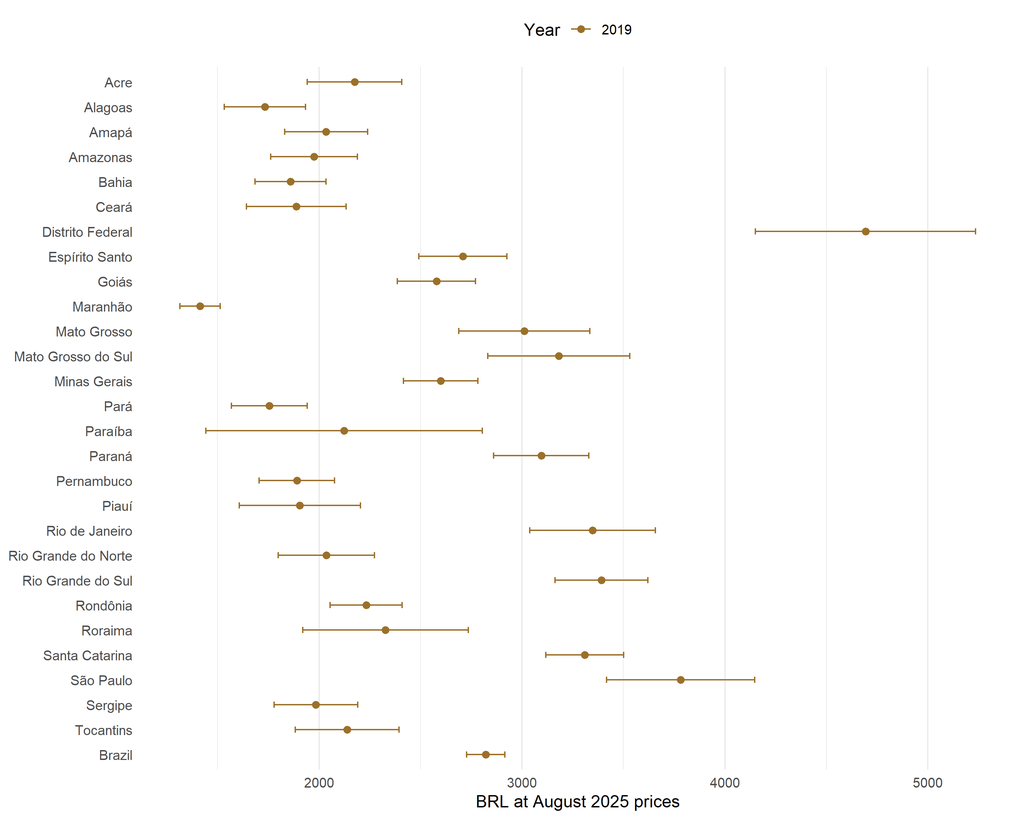

Composite individual monthly income

| UF | Year | Estimate [95% CI] | Valid n | Missing (%) |
| --- | --- | --- | --- | --- |
| Acre | 2019 | 2174.61 [1940.89; 2408.33] | 2283 | 0.00 |
| Alagoas | 2019 | 1732.62 [1532.16; 1933.09] | 2898 | 0.00 |
| Amapá | 2019 | 2034.59 [1829.98; 2239.20] | 1472 | 0.03 |
| Amazonas | 2019 | 1975.30 [1761.01; 2189.58] | 3370 | 0.00 |
| Bahia | 2019 | 1858.75 [1683.42; 2034.07] | 3600 | 0.00 |
| Ceará | 2019 | 1888.12 [1642.89; 2133.35] | 4140 | 0.03 |
| Distrito Federal | 2019 | 4692.72 [4150.27; 5235.16] | 2305 | 0.00 |
| Espírito Santo | 2019 | 2708.40 [2491.97; 2924.82] | 3461 | 0.03 |
| Goiás | 2019 | 2578.29 [2385.03; 2771.54] | 2648 | 0.00 |
| Maranhão | 2019 | 1413.44 [1314.76; 1512.12] | 4889 | 0.00 |
| Mato Grosso | 2019 | 3011.34 [2688.57; 3334.11] | 2423 | 0.00 |
| Mato Grosso do Sul | 2019 | 3181.43 [2831.09; 3531.76] | 2804 | 0.01 |
| Minas Gerais | 2019 | 2599.36 [2416.34; 2782.39] | 5126 | 0.09 |
| Pará | 2019 | 1755.11 [1567.97; 1942.25] | 3696 | 0.00 |
| Paraíba | 2019 | 2123.70 [1442.52; 2804.88] | 3068 | 0.00 |
| Paraná | 2019 | 3094.71 [2860.73; 3328.69] | 3892 | 0.02 |
| Pernambuco | 2019 | 1890.92 [1704.91; 2076.93] | 3992 | 0.00 |
| Piauí | 2019 | 1905.33 [1607.06; 2203.60] | 2674 | 0.00 |
| Rio de Janeiro | 2019 | 3347.85 [3038.77; 3656.94] | 4849 | 0.00 |
| Rio Grande do Norte | 2019 | 2035.12 [1798.05; 2272.20] | 2877 | 0.00 |
| Rio Grande do Sul | 2019 | 3392.00 [3163.46; 3620.54] | 3706 | 0.04 |
| Rondônia | 2019 | 2232.10 [2054.25; 2409.94] | 2108 | 0.00 |
| Roraima | 2019 | 2327.47 [1919.44; 2735.50] | 2135 | 0.00 |
| Santa Catarina | 2019 | 3309.15 [3117.29; 3501.00] | 3676 | 0.00 |
| São Paulo | 2019 | 3781.15 [3416.32; 4145.98] | 5995 | 0.00 |
| Sergipe | 2019 | 1984.02 [1778.00; 2190.04] | 2563 | 0.00 |
| Tocantins | 2019 | 2138.15 [1882.33; 2393.96] | 1872 | 0.00 |
| Brazil | 2019 | 2821.28 [2726.73; 2915.83] | 88522 | 0.01 |

Source: authors’ calculations using official PNS microdata.

Income totals that could not be calculated (%)

| UF | Year | Estimate [95% CI] | Valid n | Missing (%) |
| --- | --- | --- | --- | --- |
| Brazil | 2019 | 0.01% [0.00%; 0.04%] | 88531 | 0.00 |

Source: authors’ calculations using official PNS microdata.

Update factor July 2019 to August 2025: 1.40192528 .

# 10 Interoperability and reproducibility

Tables have stable identifiers and fields for eligibility, precision and provenance. Future integration with healthcare records must preserve the cross-sectional nature and design of the PNS. The survey does not provide individual care trajectories. OMOP/OHDSI documentation principles can inform complementary sources while respecting these differences (OHDSI, n.d.).

# 11 Interpretation and limitations

Comparisons of diagnosis, attacks and smoking depend on equivalent definitions and the approximation used for variance across editions. Changes in composition and access to diagnosis are possible explanations, without causal identification. Changes are not attributed to the number of respiratory physicians. Medication results require edition-specific interpretation.

Payment does not quantify costs, and respiratory causes do not identify asthma exclusively. Economic analysis for 2023–2025 requires additional sources, attribution rules and consideration of the time gap.

Excluding unknown information can introduce bias if nonresponse is associated with the outcome. Composite income requires sufficient information for all eight components, potentially selecting people with more complete records. Outputs record missingness and precision to support this assessment.

# 12 Validation and reproduction files

`tools/run_analysis.R` runs the complete analysis. Indicator entry points call the same implementation. Results pass through a staging area before publication. The manifest checks agreement between code, tables and report. Tests cover recoding, income, design, estimators and bilingual outputs. Commands and results are recorded in the validation log.

# 13 References

BROWN, Lawrence D.; CAI, T. Tony; DASGUPTA, Anirban. Interval estimation for a binomial proportion. *Statistical Science*, v. 16, n. 2, p. 101-133, 2001. doi:10.1214/ss/1009213286.

DUBE, I.; SILVA, M. E. L. *PNS_2013_2019*. GitHub, 2026. Available at: https://github.com/ingodube/PNS_2013_2019. Accessed on: May 28, 2026.

GLOBAL ASTHMA NETWORK. *Global Asthma Report 2022*. Auckland, New Zealand: Global Asthma Network, 2022. Available at: https://globalasthmareport.org/resources/Global_Asthma_Report_2022.pdf. Accessed on: September 19, 2025.

IBGE. *IPCA: número-índice, tabela SIDRA 1737*. https://sidra.ibge.gov.br/tabela/1737.

IBGE. *Pesquisa Nacional de Saúde 2013: documentação e questionário*. https://ftp.ibge.gov.br/PNS/2013/Microdados/Documentacao/.

IBGE. *Pesquisa Nacional de Saúde 2019: documentação e questionário*. https://ftp.ibge.gov.br/PNS/2019/Microdados/Documentacao/.

IBGE. *PNSIBGE: documentação de apoio para deflacionamento*. https://ftp.ibge.gov.br/PNS/Documentacao_Geral/PNSIBGE_Deflator.pdf.

KORN, Edward L.; GRAUBARD, Barry I. Confidence intervals for proportions with small expected number of positive counts estimated from survey data. *Survey Methodology*, v. 24, n. 2, p. 193-201, 1998.

LUMLEY, Thomas. *Complex Surveys: A Guide to Analysis Using R*. Hoboken: Wiley, 2010.

MENEZES, A. M. B. et al. Prevalência de diagnóstico médico de asma em adultos brasileiros: Pesquisa Nacional de Saúde, 2013. *Revista Brasileira de Epidemiologia*, São Paulo, v. 18, supl. 2, p. 204-213, 2015.

OHDSI. *ETL Creation Best Practices*. Available at: https://www.ohdsi.org/web/wiki/doku.php?id=documentation:etl_best_practices.

OHDSI. *OMOP Common Data Model*. Available at: https://ohdsi.github.io/CommonDataModel/.

OHDSI. *Standardized Data: The OMOP Common Data Model*. Available at: https://www.ohdsi.org/data-standardization/.

SANTOS, Felipe Moraes dos et al. Tendência da prevalência de asma autorreferida no Brasil de 2003 a 2013 em adultos e fatores associados à prevalência. *Jornal Brasileiro de Pneumologia*, v. 44, n. 6, p. 491-497, 2018. doi:10.1590/S1806-37562017000000328.

SEVERE ASTHMA. *Non-Pharmacological Interventions for Asthma*. Available at: https://www.severeasthma.org.au/non-pharmacological-interventions-asthma/. Accessed on: September 19, 2025.

SOUZA-JÚNIOR, Paulo Roberto Borges de et al. Desenho da amostra da Pesquisa Nacional de Saúde 2013. *Epidemiologia e Serviços de Saúde*, v. 24, p. 207-216, 2015.

TO, T. et al. Global asthma prevalence in adults: findings from the cross-sectional world health survey. *BMC Public Health*, v. 12, art. 204, 2012. doi:10.1186/1471-2458-12-204.

# Artificial intelligence disclosure

Artificial intelligence assisted implementation, prose editing and translation into English. The humanizer skill guided editorial revision while preserving definitions, references, numbers and limitations. Authorship and responsibility for scientific interpretation remain with the authors.